# Tugas ke 2 Pempro_Kelompok 1

Author

Yulia Atma Putri_M0501261027,  
Rifdah Apriliani_M0501261030,  
Nurul Hikmah Usmanah-M0501261080

# Soal 1. Pembersihan data mahasiswa

## 1. Membuat data frame

```r
nilai_raw <- data.frame(
  Nama = c("Andi", "Budi", "Citra", "Dewi", "Andi"),
  Matematika = c(80,90,NA,75,80),
  Statistika = c(85, 88, 78,"-", 85),
  Umur = c(21,20,22,21,21)
)
nilai_raw
```

```
   Nama Matematika Statistika Umur
1  Andi         80         85   21
2  Budi         90         88   20
3 Citra         NA         78   22
4  Dewi         75          -   21
5  Andi         80         85   21
```

## 2. Idenfitikasi nilai yang hilang

```r
#apakah terdapat data hilang?
is.na(nilai_raw)
```

```
      Nama Matematika Statistika  Umur
[1,] FALSE      FALSE      FALSE FALSE
[2,] FALSE      FALSE      FALSE FALSE
[3,] FALSE       TRUE      FALSE FALSE
[4,] FALSE      FALSE      FALSE FALSE
[5,] FALSE      FALSE      FALSE FALSE
```

```r
#berapa jumlah data hilang?
sum(is.na(nilai_raw))
```

```
[1] 1
```

```r
#mengubah - menjadi NA
nilai_raw$Statistika[nilai_raw$Statistika=="-"] <-NA

#mengubah Statistik menjadi integer
nilai_raw$Statistika <- as.numeric(nilai_raw$Statistika)

#sekarang berapa data yang hilang?
colSums(is.na(nilai_raw))
```

```
      Nama Matematika Statistika       Umur
         0          1          1          0
```

Berdasarkan rincian identifikasi pada data `nilai_raw`, terdapat *missing value* pada kolom `Matematika` yang ditandai dengan `NA`, yaitu format standar untuk nilai *missing* di R. Selain itu, pada kolom `Statistika` juga terdapat nilai yang hilang, tetapi masih dituliskan dalam format nonstandar berupa tanda setriip(`-`). Tanda `-` perlu diubah menjadi `NA` agar nilai yang hilang dapat dikenali dan diproses dengan benar oleh R. Total nilai hilang pada data tersebut sebanyak 2 yaitu pada kolom Matematika dan Statistika.

## 3. Imputasi nilai statistika yang kosong

Nilai `Statistika` yang kosong akan diimputasi menggunakan nilai rata-rata mahasisw lain yang tersedia.

```r
rataStat_nonNA <-mean(nilai_raw$Statistika, na.rm = TRUE)

nilai_raw$Statistika[is.na(nilai_raw$Statistika)] <- rataStat_nonNA

nilai_raw
```

```
   Nama Matematika Statistika Umur
1  Andi         80         85   21
2  Budi         90         88   20
3 Citra         NA         78   22
4  Dewi         75         84   21
5  Andi         80         85   21
```

Nilai `Statistika` Dewi yang sebelumnya hilang telah diimputasi menggunakan **rata-rata nilai Statistika mahasiswa lainnya**, sehingga diperoleh nilai sebesar **84**.

## 4. Membuat Kolom `Status_Umur`

Variabel `Status_Umur` dibuat menggunakan fungsi `ifelse()`.

Ketentuannya:

- Umur ≥ 21 tahun = Dewasa
- Umur < 21 tahun = Muda

```r
nilai_raw$Status_umur <- ifelse(nilai_raw$Umur>=21, "Dewasa","Muda")
nilai_raw
```

```
   Nama Matematika Statistika Umur Status_umur
1  Andi         80         85   21      Dewasa
2  Budi         90         88   20        Muda
3 Citra         NA         78   22      Dewasa
4  Dewi         75         84   21      Dewasa
5  Andi         80         85   21      Dewasa
```

Saat ini, pada data `nilai_raw` telah ditambahkan satu kolom baru, yaitu Status_Umur, yang merupakan hasil pengelompokan berdasarkan informasi umur mahasiswa.

## 5. Hapus data duplikat

Pemeriksaan data duplikat dilakukan menggunakan fungsi `duplicated()`.

```r
duplicated(nilai_raw)
```

```
[1] FALSE FALSE FALSE FALSE  TRUE
```

```r
#hapus duplicate
nilai_bersih <- nilai_raw[!duplicated(nilai_raw),]
nilai_bersih
```

```
   Nama Matematika Statistika Umur Status_umur
1  Andi         80         85   21      Dewasa
2  Budi         90         88   20        Muda
3 Citra         NA         78   22      Dewasa
4  Dewi         75         84   21      Dewasa
```

Saat ini, data `nilai_raw` telah melalui proses pembersihan dan penghapusan data duplikat. Setelah data duplikat Andi dihapus, jumlah mahasiswa berkurang dari **5 mahasiswa pada data awal menjadi 4 mahasiswa pada data yang telah dibersihkan**.

## 6. Simpan data ke format csv

```r
write.csv(nilai_bersih,file = "nilai_bersih.csv", row.names = FALSE)
```

# Soal 2. Subsetting dan Pengurutan Multikriteria

## 1. Membuat `data.frame profil`

```r
profil <- data.frame(
  No = 1:10,
  gender = c("f", "f", "f", "m", "m", "f", "m", "m", "f", "m"),
  v1  = c(8, 15, 8, 14, 8, 10, 9, 9, 10, 12),
  v2  = c(9, 8, 13, 9, 2, 6, 9, 10, 13, 10),
  v3  = c(5, 9, 12, 8, 9, 10, 7, 8, 6, 9),
  v4  = c(9, 5, 6, NA, 16, 9, 13, 10, 7, 8),
  v5  = c(9, 10, 7, 11, 8, 10, 9, 5, 10, 17),
  v6  = c(9, 8, 9, 10, 10, 10, 12, 10, 12, 7),
  v7  = c(5, 10, 14, 6, 8, 9, 10, 6, 13, 9),
  v8  = c(9, 12, 12, 11, 9, 7, 9, 12, 9, 10),
  v9  = c(11, 9, 12, 11, 8, 7, 11, 6, 6, 7),
  v10 = c(8, 15, 9, 8, 9, 11, 7, 8, 9, 7)
)

profil
```

```
   No gender v1 v2 v3 v4 v5 v6 v7 v8 v9 v10
1   1      f  8  9  5  9  9  9  5  9 11   8
2   2      f 15  8  9  5 10  8 10 12  9  15
3   3      f  8 13 12  6  7  9 14 12 12   9
4   4      m 14  9  8 NA 11 10  6 11 11   8
5   5      m  8  2  9 16  8 10  8  9  8   9
6   6      f 10  6 10  9 10 10  9  7  7  11
7   7      m  9  9  7 13  9 12 10  9 11   7
8   8      m  9 10  8 10  5 10  6 12  6   8
9   9      f 10 13  6  7 10 12 13  9  6   9
10 10      m 12 10  9  8 17  7  9 10  7   7
```

## 2. Penyaringan data (subsetting)

Data difilter berdasarkan dua kondisi:

- `gender = "m"` dan `v1 > 9`
- atau `gender = "f"` dan `v3 <= 10`

```r
idx <- (profil$gender=="m" & profil$v1 > 9 ) |
  (profil$gender=="f"& profil$v3 <= 10)

profil_filter <- profil[idx,]
profil_filter
```

```
   No gender v1 v2 v3 v4 v5 v6 v7 v8 v9 v10
1   1      f  8  9  5  9  9  9  5  9 11   8
2   2      f 15  8  9  5 10  8 10 12  9  15
4   4      m 14  9  8 NA 11 10  6 11 11   8
6   6      f 10  6 10  9 10 10  9  7  7  11
9   9      f 10 13  6  7 10 12 13  9  6   9
10 10      m 12 10  9  8 17  7  9 10  7   7
```

Setelah dilakukan penyaringan, data `profil` yang memenuhi salah satu kondisi, yaitu **gender laki-laki (`m`) dengan `v1 > 9`** atau **gender perempuan (`f`) dengan `v3 <= 10`**, tersisa sebanyak **6 pengamatan**.

## 3. Pengurutan data berdasarkan gender dan v5

Penguruan berdasarkan `gender` diurutkan secara *descending*;  
untuk pengamatan dengan `gender` yang sama, `v5` diurutkan secara *ascending*.

```r
idx_order <- order(profil_filter$gender !="m",
                     profil_filter$v5)

profil_filter <- profil_filter[idx_order,]
profil_filter
```

```
   No gender v1 v2 v3 v4 v5 v6 v7 v8 v9 v10
4   4      m 14  9  8 NA 11 10  6 11 11   8
10 10      m 12 10  9  8 17  7  9 10  7   7
1   1      f  8  9  5  9  9  9  5  9 11   8
2   2      f 15  8  9  5 10  8 10 12  9  15
6   6      f 10  6 10  9 10 10  9  7  7  11
9   9      f 10 13  6  7 10 12 13  9  6   9
```

Tabel di atas menunjukkan hasil pengurutan data `profil` yang telah melalui proses penyaringan. Data diurutkan berdasarkan `gender` secara *descending*. Selanjutnya, untuk pengamatan dengan `gender` yang sama, data diurutkan berdasarkan `v5` secara *ascending*.

## 4. Simpan data hasil filtering

Hasil filtering dan pengurutan disimpan sebagai `profil_filter.csv`.

```r
write.csv(profil_filter,file = "profil_filter.csv", row.names = FALSE)
```

# Soal 3. Penggabungan dan Reshaping

```r
df_sales <- data.frame(
  id_toko = c("T1", "T2", "T3"),
  Minggu1 = c(120, 150, 95),
  Minggu2 = c(135, 140, 110)
)

df_info <- data.frame(
  id = c("T1", "T2", "T4"),
  Kota = c("Jakarta", "Bandung", "Surabaya")
)
```

## 1. Penggabungan data

```r
data_gabung <- merge(df_sales, df_info, by.x= "id_toko", by.y = "id", all.x = TRUE, all.y = TRUE)

df_sales
```

```
  id_toko Minggu1 Minggu2
1      T1     120     135
2      T2     150     140
3      T3      95     110
```

```r
df_info
```

```
  id     Kota
1 T1  Jakarta
2 T2  Bandung
3 T4 Surabaya
```

```r
data_gabung
```

```
  id_toko Minggu1 Minggu2     Kota
1      T1     120     135  Jakarta
2      T2     150     140  Bandung
3      T3      95     110     <NA>
4      T4      NA      NA Surabaya
```

## 2. Reshape long

```r
penjualan_long <- reshape(data_gabung,
                          idvar = "id_toko",
                          varying = c("Minggu1", "Minggu2"),
                          v.names = "Penjualan",
                          timevar = "Minggu",
                          times = c ("Minggu1", "Minggu2"),
                          direction = "long")
penjualan_long
```

```
           id_toko     Kota  Minggu Penjualan
T1.Minggu1      T1  Jakarta Minggu1       120
T2.Minggu1      T2  Bandung Minggu1       150
T3.Minggu1      T3     <NA> Minggu1        95
T4.Minggu1      T4 Surabaya Minggu1        NA
T1.Minggu2      T1  Jakarta Minggu2       135
T2.Minggu2      T2  Bandung Minggu2       140
T3.Minggu2      T3     <NA> Minggu2       110
T4.Minggu2      T4 Surabaya Minggu2        NA
```

## 3. Simpan csv

```r
write.csv(penjualan_long,file = "penjualan_long.csv", row.names = FALSE)
```

# Soal 4. Visualisasi

Mengenali Struktur Data

```r
#6 baris awal data
head(CO2)
```

```
  Plant   Type  Treatment conc uptake
1   Qn1 Quebec nonchilled   95   16.0
2   Qn1 Quebec nonchilled  175   30.4
3   Qn1 Quebec nonchilled  250   34.8
4   Qn1 Quebec nonchilled  350   37.2
5   Qn1 Quebec nonchilled  500   35.3
6   Qn1 Quebec nonchilled  675   39.2
```

```r
#lihat sruktur data
str(CO2)
```

```
Classes 'nfnGroupedData', 'nfGroupedData', 'groupedData' and 'data.frame':  84 obs. of  5 variables:
 $ Plant    : Ord.factor w/ 12 levels "Qn1"<"Qn2"<"Qn3"<..: 1 1 1 1 1 1 1 2 2 2 ...
 $ Type     : Factor w/ 2 levels "Quebec","Mississippi": 1 1 1 1 1 1 1 1 1 1 ...
 $ Treatment: Factor w/ 2 levels "nonchilled","chilled": 1 1 1 1 1 1 1 1 1 1 ...
 $ conc     : num  95 175 250 350 500 675 1000 95 175 250 ...
 $ uptake   : num  16 30.4 34.8 37.2 35.3 39.2 39.7 13.6 27.3 37.1 ...
 - attr(*, "formula")=Class 'formula'  language uptake ~ conc | Plant
  .. ..- attr(*, ".Environment")=<environment: R_EmptyEnv>
 - attr(*, "outer")=Class 'formula'  language ~Treatment * Type
  .. ..- attr(*, ".Environment")=<environment: R_EmptyEnv>
 - attr(*, "labels")=List of 2
  ..$ x: chr "Ambient carbon dioxide concentration"
  ..$ y: chr "CO2 uptake rate"
 - attr(*, "units")=List of 2
  ..$ x: chr "(uL/L)"
  ..$ y: chr "(umol/m^2 s)"
```

```r
#lihat ringkasan data
summary(CO2)
```

```
     Plant             Type         Treatment       conc          uptake
 Qn1    : 7   Quebec     :42   nonchilled:42   Min.   :  95   Min.   : 7.70
 Qn2    : 7   Mississippi:42   chilled   :42   1st Qu.: 175   1st Qu.:17.90
 Qn3    : 7                                    Median : 350   Median :28.30
 Qc1    : 7                                    Mean   : 435   Mean   :27.21
 Qc3    : 7                                    3rd Qu.: 675   3rd Qu.:37.12
 Qc2    : 7                                    Max.   :1000   Max.   :45.50
 (Other):42
```

## 1. Hubungan `conc` dan `uptake`

Hubungan `conc` dan `uptake` dengan mengatur bentuk dan ukuran titik, warna, judul, label sumbu, serta rentang sumbu, lalu tambahkan minimal **dua elemen grafik** menggunakan `points()`, `lines()`, `abline()`, atau `text()`.

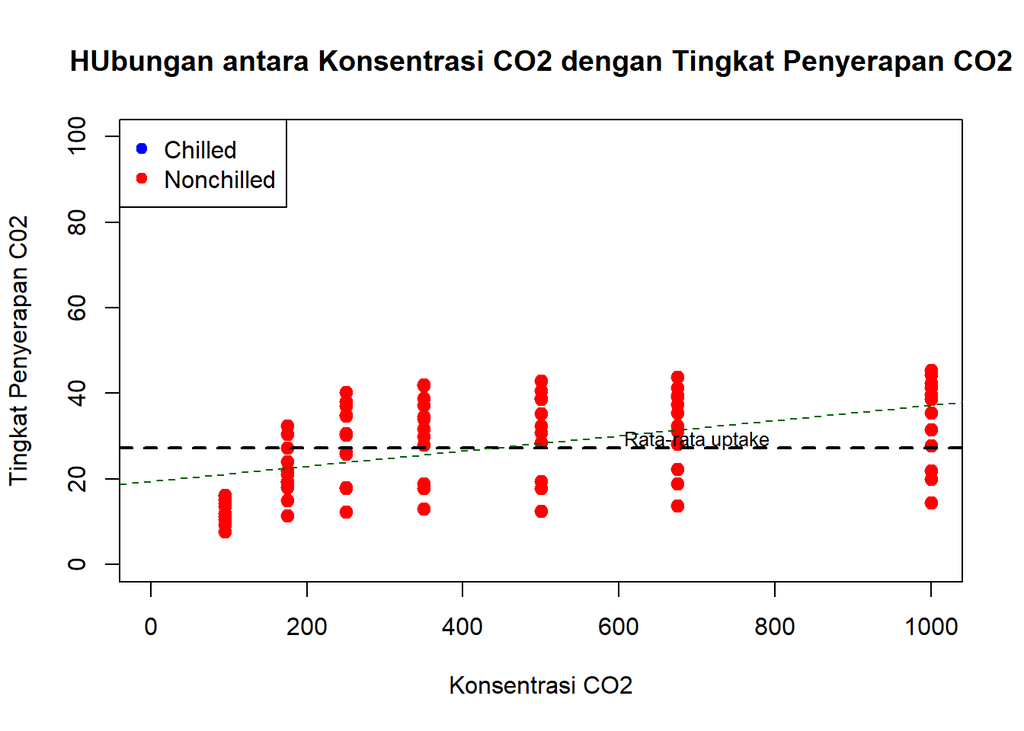

```r
#plot cond dengan uptake
plot(CO2$conc,CO2$uptake,
     pch = 19, cex = 1.2, col= "red",
     main = "HUbungan antara Konsentrasi CO2 dengan Tingkat Penyerapan CO2",
     xlab = "Konsentrasi CO2",
     ylab = "Tingkat Penyerapan C02",
     xlim = c(0,1000), ylim = c(0,100)
     )

#menambahkan garis rata conc dengan uptake
abline(h = mean(CO2$uptake),
       lty = 2,
       lwd = 2)

#menambahkan garis reg conc dengan uptake
garis_reg <- lm(uptake ~ conc, data= CO2)
abline( garis_reg , lty = 2, col= "darkgreen")

# Menambahkan keterangan pada grafik
text(700, mean(CO2$uptake) + 2,
     "Rata-rata uptake",
     cex = 0.8)

# Menambahkan legenda
legend("topleft",
       legend = c("Chilled", "Nonchilled"),
       col = c("blue", "red"),
       pch = 19)
```

**Penjelasan**

## 2. 4 grafik dalam ukuran 2x2

Tampilan grafik berukuran **2 × 2** yang terdiri atas empat jenis visualisasi berbeda untuk mengeksplorasi `conc`, `uptake`, `Type`, dan `Treatment` .

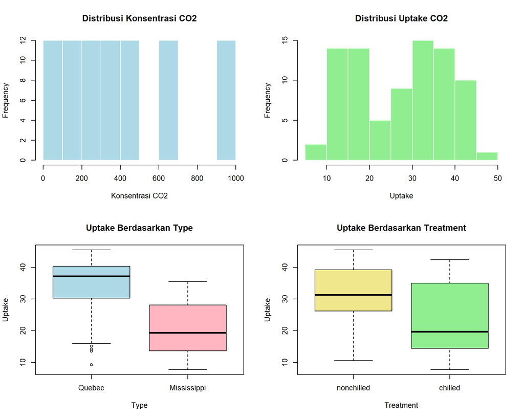

```r
# Membuat tampilan grafik 2 x 2
par(mfrow = c(2, 2))

# 1. Histogram konsentrasi CO2
hist(
  CO2$conc,
  main = "Distribusi Konsentrasi CO2",
  xlab = "Konsentrasi CO2",
  col = "lightblue",
  border = "white"
)

# 2. Histogram uptake
hist(
  CO2$uptake,
  main = "Distribusi Uptake CO2",
  xlab = "Uptake",
  col = "lightgreen",
  border = "white"
)

# 3. Boxplot uptake berdasarkan Type
boxplot(
  uptake ~ Type,
  data = CO2,
  main = "Uptake Berdasarkan Type",
  xlab = "Type",
  ylab = "Uptake",
  col = c("lightblue", "lightpink")
)

# 4. Boxplot uptake berdasarkan Treatment
boxplot(
  uptake ~ Treatment,
  data = CO2,
  main = "Uptake Berdasarkan Treatment",
  xlab = "Treatment",
  ylab = "Uptake",
  col = c("khaki", "lightgreen")
)
```

```r
# Mengembalikan tampilan grafik ke 1 panel
par(mfrow = c(1, 1))
```

Empat grafik tersebut digunakan untuk melihat karakteristik data dari beberapa sisi. Histogram digunakan untuk melihat distribusi `conc` dan `uptake`, sedangkan boxplot digunakan untuk membandingkan tingkat `uptake` berdasarkan `Type` dan `Treatment`.

## 3. Grafik dengan `qplot()`

`qplot()` untuk membuat visualisasi cepat hubungan `conc` dan `uptake` berdasarkan `Treatment`, kemudian buat kembali visualisasi tersebut menggunakan `ggplot2` dengan memetakan `Treatment` dan `Type` ke **atribut visual yang berbeda** di dalam `aes()` serta menggunakan `geom_*` yang sesuai.

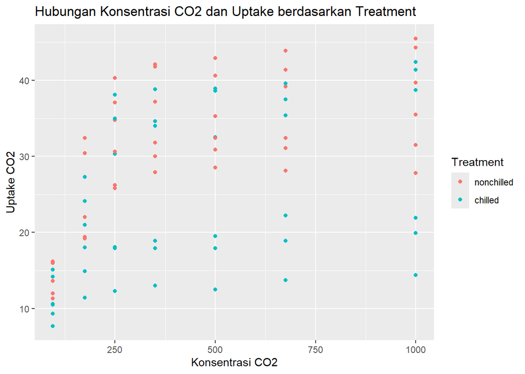

```r
library(ggplot2)

qplot(x = conc,
      y = uptake,
      data = CO2,
      color = Treatment,
      geom = "point",
      main = "Hubungan Konsentrasi CO2 dan Uptake berdasarkan Treatment",
      xlab = "Konsentrasi CO2",
      ylab = "Uptake CO2")
```

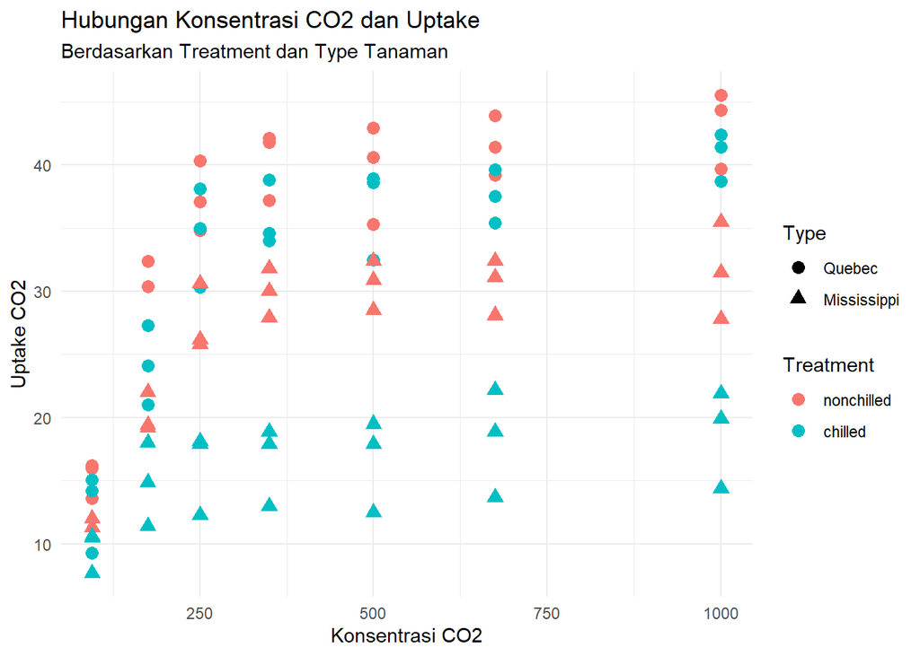

```r
#dengan menggunakang ggplot
ggplot(CO2, aes(x = conc,
                y = uptake,
                color = Treatment,
                shape = Type)) +
  geom_point(size = 3) +
  labs(
    title = "Hubungan Konsentrasi CO2 dan Uptake",
    subtitle = "Berdasarkan Treatment dan Type Tanaman",
    x = "Konsentrasi CO2",
    y = "Uptake CO2",
    color = "Treatment",
    shape = "Type"
  ) +
  theme_minimal()
```

## 4. Dengan penambahan Scale

grafik `ggplot2` no.3 dengan menambahkan minimal satu `stat_*`, satu `scale_*`, serta salah satu `coord_*`, kemudian lengkapi grafik menggunakan `labs()` dan `theme()` atau salah satu tema siap pakai agar grafik lebih informatif dan mudah dibaca.

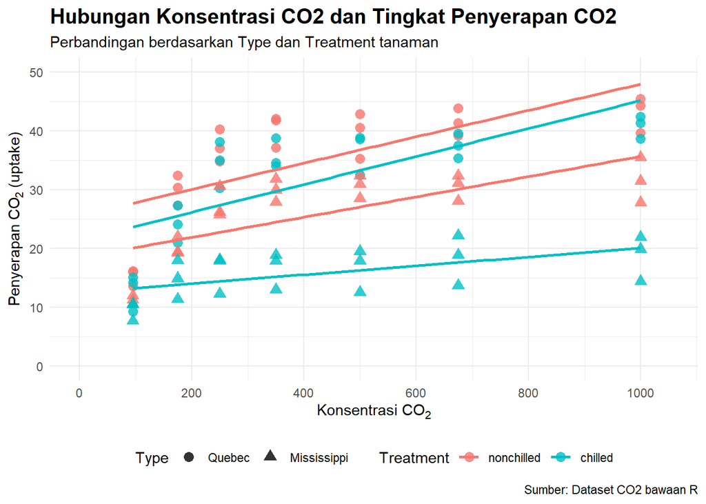

```r
grafik_akhir <-
#grafik awal
ggplot(CO2,
       aes( x= conc, y= uptake,
            color = Treatment,
            shape = Type))+
  geom_point(
    size = 3,
    alpha = 0.8
  ) +

  # stat_*
  stat_smooth( method = "lm",
    se = FALSE,
    linewidth = 1
  )+

  # scale_*
  scale_x_continuous(
    breaks = seq(0, 1000, by = 200),
    limits = c(0, 1100)
  ) +

  scale_y_continuous(
    breaks = seq(0, 100, by = 10)
  ) +

  # coord_*
  coord_cartesian(
    xlim = c(0, 1050),
    ylim = c(0, 50)
  ) +

  labs(
    title = "Hubungan Konsentrasi CO2 dan Tingkat Penyerapan CO2",
    subtitle = "Perbandingan berdasarkan Type dan Treatment tanaman",
    x = expression("Konsentrasi CO"[2]),
    y = expression("Penyerapan CO"[2]~"(uptake)"),
    color = "Treatment",
    shape = "Type",
    caption = "Sumber: Dataset CO2 bawaan R"
  ) +

  theme_minimal() +

  theme(
    plot.title = element_text(
      face = "bold",
      size = 15
    ),
    plot.subtitle = element_text(
      size = 11
    ),
    legend.position = "bottom"
  )
grafik_akhir
```

## 5. Simpan grafik

Simpan grafik akhir menggunakan `ggsave()` dalam format PNG dengan nama **`co2_uptake_visualisasi.png`**, kemudian tuliskan interpretasi mengenai hubungan antara konsentrasi CO₂ dan `uptake` serta perbedaan pola yang terlihat berdasarkan `Type` dan `Treatment`.

```r
ggsave(filename = "co2_uptake_visualisasi.png",
       plot = grafik_akhir,
       width = 7, height = 5 , dpi = 300
       )
```

**Note**

**Kesimpulan**: Berdasarkan hasil eksplorasi visual, terlihat adanya kecenderungan hubungan positif antara konsentrasi CO₂ dan tingkat penyerapan CO₂ (*uptake*). Semakin tinggi konsentrasi CO₂, tingkat penyerapan CO₂ cenderung meningkat. Namun, pada konsentrasi CO₂ yang semakin tinggi, peningkatan tingkat penyerapan mulai melambat dan cenderung stagnan.

Berdasarkan tipe tanaman, tanaman **Quebec** secara umum menunjukkan tingkat penyerapan CO₂ yang lebih tinggi dibandingkan tanaman **Mississippi**. Sementara itu, berdasarkan perlakuan (*treatment*), tanaman dengan perlakuan **nonchilled** cenderung memiliki tingkat penyerapan CO₂ yang lebih tinggi dibandingkan tanaman dengan perlakuan **chilled**. Dengan demikian, berdasarkan pola yang terlihat pada visualisasi, kombinasi tanaman **Quebec dengan perlakuan nonchilled** menunjukkan tingkat penyerapan CO₂ yang paling baik dibandingkan kelompok lainnya.